# 两分类问题中AUC指标

## 定义

分类器的评价常用指标有准确率、F1值、AUC等。其中AUC是来源于[ROC曲线](https://en.wikipedia.org/wiki/Receiver_operating_characteristic)或者叫做受试者曲线。ROC曲线横轴是FPR（False Positive Rate 假阳性率，即判断为正例但实际为负例的比例），纵轴是TPR（True Positive Rate 真阳性率，即判断为正例且实际为正例的个数占全部正例的比例）。ROC曲线只对二分类问题有效，而尤其当正负样本不平衡时，这种评价比起准确率更有效，当然也可以用F1值评价，但是F1值依赖于判别阈值的选取，而AUC没有这个问题。

AUC定义为ROC曲线下的面积，实际计算中样本数目有限，常用数值积分的方法近似计算。根据定义可以得到如下公式 $$ AUC = \int_{-\infty}^{\infty} TPR(T) d FPR(T) \\ FPR = \frac{\#FP}{\#N} \\ TPR = \frac{\#TP}{\#P} $$ 其中T是阈值，也是最终模型输出的统计变量，比如Logistic Regression输出的概率值，取值为[0,1]，一般地认为T取值范围是$\mathbb{R}$。 FP是错的正例数目（实际是负例），N是负例总数，TP是对的正例数目，P是总的正例数目。

## 物理意义

AUC有一个物理意义是说，随机从D1和D0中取出一个正样本和负样本，他们的统计量分别为$T'$和$T$，那么$T'>T$的概率就是AUC。

下面证明这个说法，将TPR的表达式代入AUC表达式有 $$ AUC = \int_{-\infty}^{\infty} \int_T^{\infty} p_1(T') p_0(T) d T dT' $$ 这是个二重积分，积分区域是 $$ D(T,T') = {(T,T'):T'>T} $$ 而$ p_0(T) d T$和$ p_1(T') d T'$分别是上述随机取出的两个的统计量落在$(T',T'+dT')$和$(T,T+dT)$区间的概率微元，因此上式就是$T'>T$的概率，这样就证明了上述论断。

## AUC的例子

下面以Python的[scikit-learn](http://scikit-learn.org)工具包为例计算模型的AUC，使用工具包自带的iris数据集。

```python
import sklearn
from sklearn.datasets import load_iris
from sklearn.linear_model import LogisticRegression
import matplotlib.pyplot as plt

plt.style.use('ggplot')
%matplotlib inline

iris = load_iris()
```

可视化数据，仅仅以前面两维特征作为模型的输入，鸢尾花数据集参考UCI中的说明。

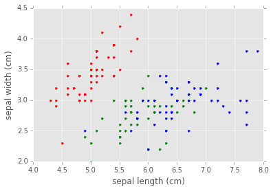

```python
plt.plot(iris.data[iris.target==0,0], iris.data[iris.target==0,1], 'r.')
plt.plot(iris.data[iris.target==1,0], iris.data[iris.target==1,1], 'g.')
plt.plot(iris.data[iris.target==2,0], iris.data[iris.target==2,1], 'b.')

plt.xlabel(iris.feature_names[0])
plt.ylabel(iris.feature_names[1])
```

```python
lr = LogisticRegression(C=1e-4)
X = iris.data[:,:2]
Y = iris.target==0
lr.fit(X,Y)
lr.score(X,Y)
```

```
0.66666666666666663
```

```
AUC: 0.9124
```

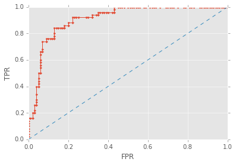

```python
from sklearn.metrics import roc_auc_score,roc_curve,auc
fpr, tpr, t = roc_curve(Y,lr.predict_proba(X)[:,1])
plt.plot(fpr, tpr,'.-')
plt.plot(fpr,fpr,'--')
plt.xlabel('FPR')
plt.ylabel('TPR')
print 'AUC:',auc(fpr,tpr)
```

红色的线是模型预测的结果，而蓝色的线代表随机猜测的结果，红色线就是ROC曲线，该曲线下的面积就是AUC，越接近于1表明模型越好。